# Do Blood Lipids Cause Coronary Heart Disease? A Two-Sample Mendelian Randomization

Pan-UK Biobank lipid GWAS (exposures) × FinnGen R12 coronary heart disease GWAS (outcome)

Author

Zi-Jie Liu

## Summary

Genetic variants that raise a lipid trait act like a lifelong randomized “treatment”. Comparing their effects on the lipid with their effects on coronary heart disease (CHD) estimates the causal effect of the lipid itself.

- **LDL cholesterol and apolipoprotein B are causal for CHD.** Per 1-SD higher LDL-C, CHD odds rise by 46% (IVW OR 1.46 (1.32 to 1.61)). All five robust methods agree.
- **Triglycerides look causal on their own, but not once ApoB is accounted for.** In the multivariable model with ApoB and HDL-C, the TG odds ratio falls from 1.23 to 1.05 (1.00 to 1.11), consistent with TG-rich lipoproteins acting mostly through the number of ApoB-containing particles (the MR-Egger version leaves a small residual effect, OR 1.07).
- **HDL cholesterol keeps an inverse association** (multivariable OR 0.89 (0.85 to 0.93)). HDL-raising drugs (CETP inhibitors, niacin) failed in trials, so this is more likely residual pleiotropy than a target (see Limitations).

## Data and design

|  | Exposure | Outcome |
| --- | --- | --- |
| Source | Pan-UK Biobank, European ancestry | FinnGen release 12, endpoint I9_CHD |
| Traits | LDL-C, HDL-C, triglycerides, ApoB (inverse-rank-normalised, per SD) | Coronary heart disease (log-odds) |
| Sample size | ~400,000 per lipid | ~500,000 (Finnish) |
| Build | GRCh37 | GRCh38, matched by rsID |

The two samples do not overlap, which avoids the bias toward the observational association that sample overlap causes in two-sample MR.

**Instruments.** SNPs with p < 5×10⁻⁸ for the lipid, LD-clumped at r² < 0.001 within 10 Mb using 1000 Genomes European genotypes (prepared in project 02), mapped to rsIDs from the 1000 Genomes VCFs, then harmonised to the same effect allele. Palindromic SNPs were kept only when allele frequency resolved the strand.

| Exposure | Instruments | Mean F-statistic |
| --- | --- | --- |
| LDL-C | 162 | 189 |
| HDL-C | 354 | 135 |
| Triglycerides | 292 | 142 |
| ApoB | 180 | 193 |

All F-statistics are far above 10, so weak-instrument bias is negligible.

## Univariable MR

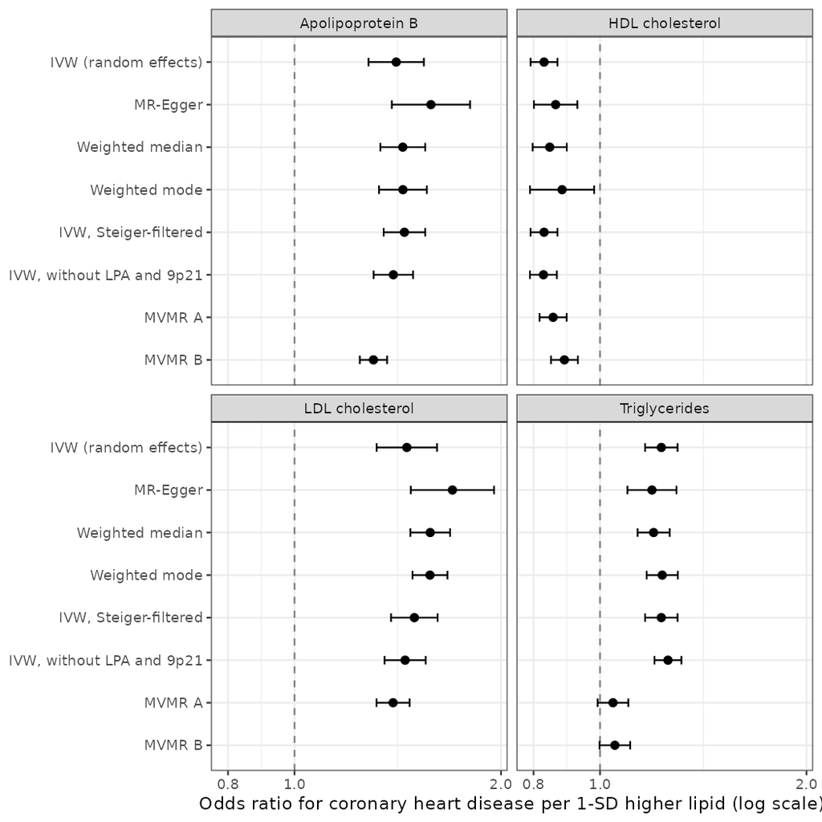

| Exposure | Method | SNPs | OR per SD (95% CI) | p |
| --- | --- | --- | --- | --- |
| Apolipoprotein B | IVW (random effects) | 180 | 1.41 (1.28 to 1.54) | 6.1e-13 |
| Apolipoprotein B | MR-Egger | 180 | 1.58 (1.39 to 1.80) | 8.3e-12 |
| Apolipoprotein B | Weighted median | 180 | 1.44 (1.33 to 1.55) | < 2e-16 |
| Apolipoprotein B | Weighted mode | 180 | 1.44 (1.33 to 1.56) | < 2e-16 |
| Apolipoprotein B | IVW, Steiger-filtered | 178 | 1.45 (1.35 to 1.55) | < 2e-16 |
| Apolipoprotein B | IVW, without LPA and 9p21 | 175 | 1.39 (1.30 to 1.49) | < 2e-16 |
| HDL cholesterol | IVW (random effects) | 354 | 0.83 (0.79 to 0.87) | 3.4e-16 |
| HDL cholesterol | MR-Egger | 354 | 0.86 (0.80 to 0.93) | 6.0e-05 |
| HDL cholesterol | Weighted median | 354 | 0.84 (0.80 to 0.89) | 7.4e-09 |
| HDL cholesterol | Weighted mode | 354 | 0.88 (0.79 to 0.98) | 0.02 |
| HDL cholesterol | IVW, Steiger-filtered | 354 | 0.83 (0.79 to 0.87) | 3.4e-16 |
| HDL cholesterol | IVW, without LPA and 9p21 | 352 | 0.83 (0.79 to 0.87) | < 2e-16 |
| LDL cholesterol | IVW (random effects) | 162 | 1.46 (1.32 to 1.61) | 3.1e-13 |
| LDL cholesterol | MR-Egger | 162 | 1.70 (1.48 to 1.95) | 1.1e-13 |
| LDL cholesterol | Weighted median | 162 | 1.58 (1.48 to 1.69) | < 2e-16 |
| LDL cholesterol | Weighted mode | 162 | 1.58 (1.49 to 1.67) | < 2e-16 |
| LDL cholesterol | IVW, Steiger-filtered | 161 | 1.50 (1.38 to 1.62) | < 2e-16 |
| LDL cholesterol | IVW, without LPA and 9p21 | 157 | 1.45 (1.35 to 1.55) | < 2e-16 |
| Triglycerides | IVW (random effects) | 292 | 1.23 (1.16 to 1.30) | 1.4e-13 |
| Triglycerides | MR-Egger | 292 | 1.19 (1.10 to 1.29) | 3.3e-05 |
| Triglycerides | Weighted median | 292 | 1.20 (1.13 to 1.26) | 6.0e-11 |
| Triglycerides | Weighted mode | 292 | 1.23 (1.17 to 1.30) | 4.6e-15 |
| Triglycerides | IVW, Steiger-filtered | 292 | 1.23 (1.16 to 1.30) | 1.4e-13 |
| Triglycerides | IVW, without LPA and 9p21 | 288 | 1.26 (1.20 to 1.31) | < 2e-16 |

How the methods guard against invalid instruments:

| Method | Assumption it relaxes |
| --- | --- |
| MR-Egger | Pleiotropy allowed if independent of instrument strength (InSIDE); intercept tests directional pleiotropy |
| Weighted median | Consistent if ≥50% of the weight comes from valid instruments |
| Weighted mode | Consistent if the largest group of instruments with similar estimates is valid |
| Steiger filtering | Drops SNPs that explain more variance in CHD than in the lipid (reverse direction) |
| Without LPA and 9p21 | Removes two known non-lipid CHD loci: Lp(a) and CDKN2B-AS1 |

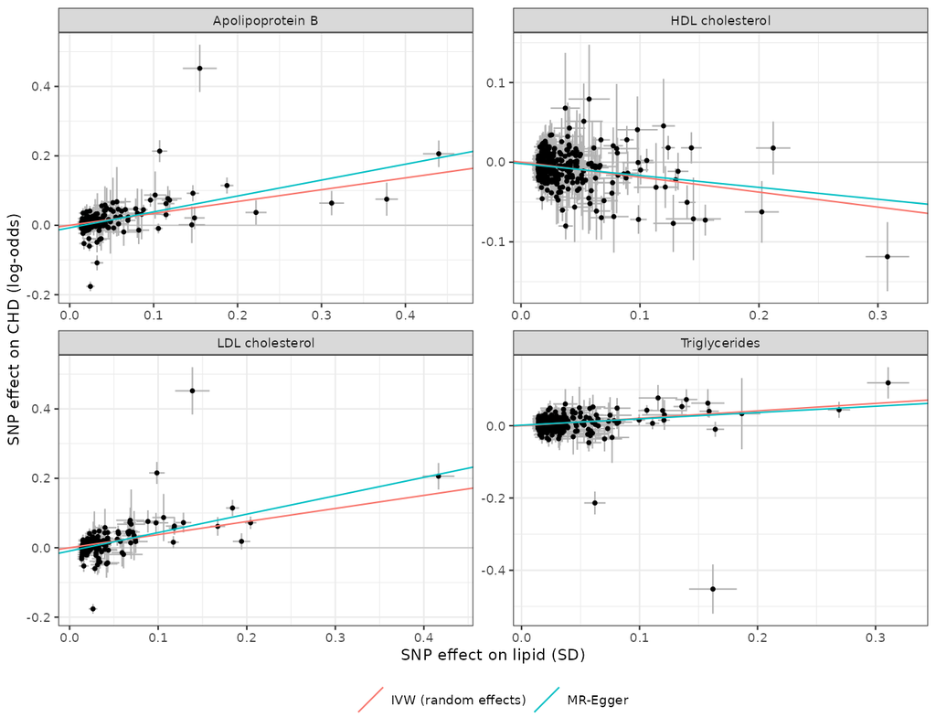

Each point is one SNP. The LPA variants (top of the LDL and ApoB panels) and the 9p21 variant (bottom) are the clearest outliers; removing them barely moves the estimates.

Cochran’s Q is large for every exposure (p < 1e-90), so there is substantial heterogeneity, and the MR-Egger intercept is non-zero for LDL-C (p = 0.002). That is why the random-effects IVW and the robust methods, not fixed-effect IVW, carry the conclusions.

## Multivariable MR

Lipid traits share many variants, so univariable estimates can borrow each other’s effects. Multivariable MR estimates each trait’s direct effect.

| Model | Exposure | Method | SNPs | OR per SD (95% CI) | p |
| --- | --- | --- | --- | --- | --- |
| A: LDL + HDL + TG | LDL cholesterol | Multivariable IVW | 855 | 1.39 (1.32 to 1.47) | < 2e-16 |
| A: LDL + HDL + TG | HDL cholesterol | Multivariable IVW | 855 | 0.85 (0.82 to 0.89) | 1.1e-11 |
| A: LDL + HDL + TG | Triglycerides | Multivariable IVW | 855 | 1.04 (0.99 to 1.10) | 0.0978 |
| A: LDL + HDL + TG | LDL cholesterol | Multivariable MR-Egger | 855 | 1.48 (1.39 to 1.58) | < 2e-16 |
| A: LDL + HDL + TG | HDL cholesterol | Multivariable MR-Egger | 855 | 0.87 (0.83 to 0.91) | 8.4e-10 |
| A: LDL + HDL + TG | Triglycerides | Multivariable MR-Egger | 855 | 1.07 (1.01 to 1.12) | 0.0146 |
| B: ApoB + HDL + TG | Apolipoprotein B | Multivariable IVW | 855 | 1.30 (1.24 to 1.36) | < 2e-16 |
| B: ApoB + HDL + TG | HDL cholesterol | Multivariable IVW | 855 | 0.89 (0.85 to 0.93) | 2.1e-07 |
| B: ApoB + HDL + TG | Triglycerides | Multivariable IVW | 855 | 1.05 (1.00 to 1.11) | 0.0579 |
| B: ApoB + HDL + TG | Apolipoprotein B | Multivariable MR-Egger | 855 | 1.35 (1.28 to 1.42) | < 2e-16 |
| B: ApoB + HDL + TG | HDL cholesterol | Multivariable MR-Egger | 855 | 0.89 (0.85 to 0.93) | 6.2e-07 |
| B: ApoB + HDL + TG | Triglycerides | Multivariable MR-Egger | 855 | 1.07 (1.02 to 1.13) | 0.0092 |

## Do the European instruments carry over to East Asians?

The same instruments’ lipid effects in the Pan-UKB East Asian sample (about 2,500 people) were regressed on their European effects.

| Exposure | SNPs | Same direction | EAS effect / EUR effect (slope) |
| --- | --- | --- | --- |
| ApoB | 173 | 71% | 0.51 |
| HDL-C | 338 | 67% | 0.69 |
| LDL-C | 158 | 70% | 0.59 |
| Triglycerides | 281 | 61% | 0.44 |

Most instruments point the same way, but East Asian effects are about half the European size. Part of that is winner’s curse in the European discovery GWAS and noise in the small East Asian sample. An East Asian MR therefore needs East Asian instruments, for example from Biobank Japan or Taiwan Biobank.

## Limitations

- Pleiotropy is substantial (large Q). The robust methods agree, but none of them can rule it out completely, and the HDL-C result illustrates this.
- Exposure effects are per SD of inverse-rank-normalised traits, not mg/dL.
- FinnGen is a founder population; allele frequencies differ slightly from UK Biobank (harmonisation checks this).
- Effect sizes are lifelong genetic differences and are larger than the effect of lowering lipids for a few years with a drug.

## Reproduce

```bash
bash R/00_download_sumstats.sh    # stream and slim the public GWAS files
Rscript R/01_instruments.R        # select, clump and annotate instruments
Rscript R/02_outcome_harmonise.R  # look up in FinnGen and align alleles
Rscript R/03_mr.R                 # MR, MVMR, figures
quarto render report.qmd
```